# 一、 折让率、折后价与月售关系

# 二、单品售价及单品月销售情况

# 售价波动在13+-6之间，且售价集中趋势明显，售价和月售相关性基本无（未考虑曾经打折的情况）

# 单品月售的波动在3+-8之间，波动幅度大，且偏态明显（售价0和低销售居多）

# 直接降价促销的效果可能有限，需要形成重点单品

```python
pd.concat([pd.DataFrame(i) for i in productss]).to_excel('check2.xlsx')
```

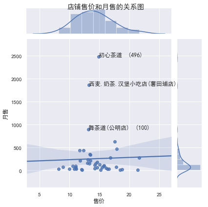

```python
productt.groupby('店名')[['月售','售价']].aggregate({'月售':np.sum,'售价':np.mean})
productt1 = productt.groupby('店名')[['月售','售价']].aggregate({'月售':np.sum,'售价':np.mean}).sort_values(by='月售',ascending=False)[:3]
sns.jointplot(x="售价", y="月售", data=productt.groupby('店名')[['月售','售价']].aggregate({'月售':np.sum,'售价':np.mean}), kind="reg")
plt.suptitle('店铺售价和月售的关系图')
for i in range(3):
    plt.text(productt1.iloc[i,:][1], productt1.iloc[i,:][0], productt1.iloc[i,:].name)
```

# 个别的高销售现象 证明市场偏向寡头市场可能形成的原因为高销售单品的垄断（月销售高对销售有促进作用）

```python
def checkjunck(i):
    type = ''
    if '现磨' in  i or  '汤圆' in i  or    '冷'  in i  or '杯' in  i or '欧蕾'in  i   or  '凉粉' in  i or    '蜂蜜'  in  i  or  '玫瑰'  in   i  or    '手磨' in i or  '格雷'  in  i  or  '拿铁' in  i or '玛奇朵' in  i  or  '益力多' in  i   or   '柠' in  i or '雪碧' in   i   or  '可乐' in  i or '招牌' in  i or '汁' in i or  '葡萄' in i or   '爽' in i or  '粉圆' in  i or     '马蹄' in i or  '布丁'  in i or '花' in i  or '玉' in i or '水' in i or '冻'  in  i  or '巧克力'in  i or '桔' in i  or  '柠' in  i or '豆' in  i  or   '茉莉' in i or '冰'  in  i  or '糖水' in i or '桂圆' in i  or  '红枣' in i  or '雪耳' in i or '橘' in i or'珍珠' in i or '红豆' in i or '西米' in i  or '仙草' in  i or  '原味' in i or '原香' in i or   '莓' in i or  '柚' in i or '布蕾' in i or '饮' in i or  '梅' in i  or '桃' in i or '梨' in i or   '百香' in i or '咖啡' in i or '香草' in i or'奥利奥' in i or '芝士' in i or '露' in i or  '黑砖' in i or  '果' in i or '瓜' in i or '茶' in i or '奶' in i or '霜降' in i or '乌龙' in i or '水果' in i or '芒' in i or '金桔' in i or '四季春' in i or '橙' in i or '百香果' in i or '柠檬' in i or"抹茶"  in i or   '布雷' in  i:
        type =  '饮品'
    elif'关东煮' in   i or '丹麦'  in  i  or  '吐司' in  i   or  '培根'  in   i  or  '肠' in  i or   '圈' in i  or   '糕' in i or '酱'  in  i  or     '骨'  in  i    or '嫩' in  i   or '馒头'  in i or  '粥' in  i or   '吃' in  i or '蟹' in i or '袋' in i  or'个' in i or  '牛' in i or  '包' in i or  '碳烧' in i or    '鸭' in i or  '卡布' in i  or '腿' in i or '海带' in i or  '竹笋' in i or  '紫薯' in i or    '泡芙' in  i or '丸' in i or '鱼' in i  or '派'in i or'面' in i or '肉' in i or '堡' in  i or '辣' in i or  '卤' in i or  '鱼蛋' in i or '酥' in i or '球' in i or '蛋糕' in i or'热狗' in i or '披萨' in i or '虾' in i or '脆皮' in i or '卷'in i or'串'  in i or '手抓饼' in i or '鸡排' in i or '鸡蛋'  in i  or '千层' in i or "鸡柳"  in i or'骨肉相连'  in i or '奥尔良' in i or '翅' in i or '薯条' in i  or '饼'  in  i or '地瓜' in i or '芋'  in i or '鸡' in i:

        type = '小吃'
    elif '套餐' in i :
        type = '套餐'
    else:
        type = '饮品2'
    return type
```

```python
productt['类型']=productt['产品'].apply(checkjunck)
```

```python
tablell = pd.concat([pd.DataFrame(i) for i in productss])
```

```python
tablell['客单品'] = [len(i) for i in tablell.iloc[:,1]]
```

```
客单品
1     0.101036
2     0.470984
3     0.194819
4     0.089119
5     0.040415
6     0.012435
7     0.007254
8     0.002591
9     0.001036
11    0.000518
13    0.000518
Name: 客单品, dtype: float64
```

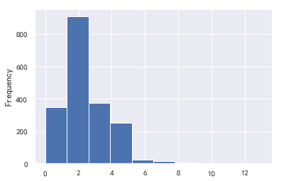

```python
tablell['客单品'].plot.hist()
tablell[tablell['客单品']!=0].groupby('客单品')['客单品'].count()/len(tablell)
```